# RAISING demonstration

RAISING is a neural network(NN) framework implemented in a two stage approach, first performing hyperparameter tuning to devise the best NN architecture then training on the data to estimate the feature importance. Here we describe the functionality of RAISING on a simulated data, this will involve introduction of various hyperparameter tuning and feature selection methods.

## Import required libraries

```python
import pandas as pd
from RAISING.hp_tune_select import *
```

## Load simulated data

We will use the simulated data from capblancq et. al.(2018) stored in sim1.csv. There are 64 population and authors have sampled 10 individuals from each of the the population at the end of simulations. Simulated data has 640 individuals and 1000 Loci which is input data and output data has 640 individuals and 10 environmental factors.

```python
df = pd.read_csv("sim1.csv")
```

We will store the input genotype matrix into X_data variable and environmental matrix in y_data

```python
X_data = df.iloc[:,14:]
X_data.columns = ["X" + str(i) for i in range(1, X_data.shape[1]+1)]

y_data = df.iloc[:,1:11]
print(X_data.head())
print(y_data.head())
```

## Hyperparameter tuning methods implementation

We will use hp_optimization() function defined in RAISING for hyperparameter tuning.The description of the function can be found in README file **README_RAISING.html**. We will use various methods for hyperparameter tuning and then we will perform feature selection using various methods described in documentation.

Since the supervised learning task is **Regression** the default loss function is *mse* and metric is *R-squared*. In this example we have closedn validation loss(val_loss) as the objective function to be minimised. These are keras and tensorflow parameters which can be changed if needed.

### 1) Hyperparameter tuning using *Bayesian optimization*

```python
Bayesian_tune_model = hp_optimization(input_data=X_data, output_data=y_data, objective_fun="val_loss", output_class="continuous",
                                      algorithm = "Bayesian",model_file = "Bayesian_NN_architecture_HP.keras", max_trials=30)
```

```python
print(Bayesian_tune_model.summary())
```

### 2) Hyperparameter tuning using *RandomSearch*

```python
RS_tune_model = hp_optimization(input_data=X_data, output_data=y_data, objective_fun="val_loss", output_class="continuous",
                                algorithm = "RandomSearch",model_file = "RS_NN_architecture_HP.keras", max_trials=50)
```

```python
print(RS_tune_model.summary())
```

### 3) Hyperparameter tuning using *RSLM*

```python
RSLM_tune_model = hp_optimization(input_data=X_data, output_data=y_data, objective_fun="val_loss", output_class="continuous",
                                  algorithm = "RSLM",model_file = "RSLM_NN_architecture_HP.keras", max_trials=50)
```

```python
print(RSLM_tune_model.summary())
```

### 4) Hyperparameter tuning using *Hyperband*

```python
Hyperband_tune_model = hp_optimization(input_data=X_data, output_data=y_data, objective_fun="val_loss", output_class="continuous",
                                       algorithm = "Hyperband",model_file = "Hyperband_NN_architecture_HP.keras", max_epochs=20)
```

```python
print(Hyperband_tune_model.summary())
```

### 5) Hyperparameter tuning using *Bayesian optimization* with *cross-validation*

In the previous examples, we have performed hyperparamter tuning based on train-test-split strategy.

By specifying the parameter **cross_validation = True**, we can perform the K-fold cross validation. By default 3-Fold **(n_splits = 3)** is performed.

```python
Bayesian_CV_tune_model = hp_optimization(input_data=X_data, output_data=y_data, objective_fun="val_loss", output_class="continuous",
                                         algorithm = "Bayesian",model_file = "Bayesian_CV_NN_architecture_HP.keras",
                                         cross_validation = True,max_trials=20)
```

### 5) Hyperparameter tuning using *Bayesian optimization* with user-defined *hyperparameter space*

We will use hyperparameter_config.json file for this example. Here we only perform L1 regularization.

```python
Bayesian_US_tune_model = hp_optimization(input_data=X_data, output_data=y_data, objective_fun="val_loss", output_class="continuous",
                                         algorithm = "Bayesian",model_file = "Bayesian_US_NN_architecture_HP.keras",max_trials=20,
                                        config_file = "hyperparameter_config.json")
```

### Creating a function to generate the plots of feature importance estimates

We will scale the feature importance of genetic loci between [0,1] corresponding to linear environment gradient(envir2). We will generate a plot where we will have on the x-axis (genetic loci position) and on the y-axis (feature importance corresponding to linear environment)

```python
import matplotlib.pyplot as plt
import numpy as np

actual_pos = [101,111,121,131,141,151,161,171,181,191]

def minmaxscale(vec):
        return((vec - min(vec))/(max(vec) - min(vec)))

def plot_feature_importance(GenFeat_df,actual_pos):
    GenFeat_df["scaled_feat"] = minmaxscale(vec = GenFeat_df["envir2"])
    GenFeat_df["loci_index"] = GenFeat_df.index+1
    plt.figure(figsize=(10, 6))
    plt.plot(GenFeat_df['loci_index'], GenFeat_df['scaled_feat'], marker='o', linestyle='-', color='b')
    highlight_df = GenFeat_df[GenFeat_df['loci_index'].isin(actual_pos)]
    plt.scatter(highlight_df['loci_index'], highlight_df['scaled_feat'], color='red', zorder=5)
    plt.title('Line Plot of Scaled Features by Loci corresponding to linear environment')
    plt.xlabel('Loci Index')
    plt.ylabel('Scaled Feature')
    plt.grid(True)
    plt.show()
```

## Feature Selection methods implementation on architecture obtained using Bayesian optimization

We will use feature_importance() function defined in RAISING for feature selection.The description of the function can be found in README file **README_RAISING.html**.

Here we will specify **iteration** parameter to perform feature importance based on a single iteration of model training. For the tutorial purpose, we restricted ourselves to architecture obtained using Bayesian method, **Bayesian_NN_architecture_HP.keras**

### 1) DeepFeatImp method

**Feature Importance based on single iteration of model training (iteration =1)**

```python
DeepFeatImp_df = feature_importance(input_data=X_data, output_data=y_data, feature_set=X_data.columns.to_list(),iteration=1,
                                    feature_method="DeepFeatImp",model_file = "Bayesian_NN_architecture_HP.keras")
```

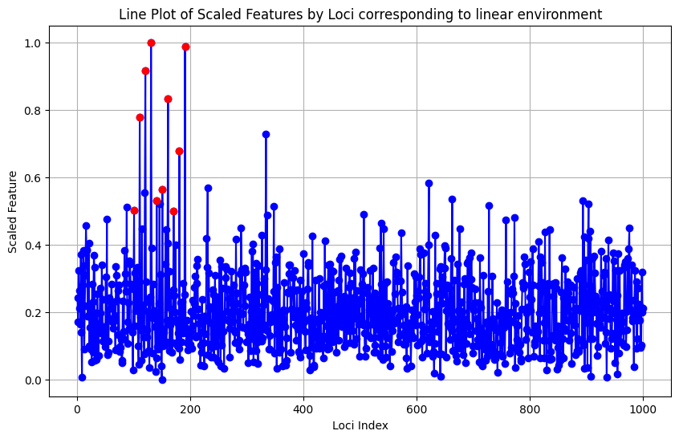

```python
plot_feature_importance(GenFeat_df=DeepFeatImp_df.copy(),actual_pos = actual_pos)
```

**Feature Importance based on five iterations of model training (iteration =5)**

```python
DeepFeatImp_df = feature_importance(input_data=X_data, output_data=y_data, feature_set=X_data.columns.to_list(),iteration=5,
                                    feature_method="DeepFeatImp",model_file = "Bayesian_NN_architecture_HP.keras")
```

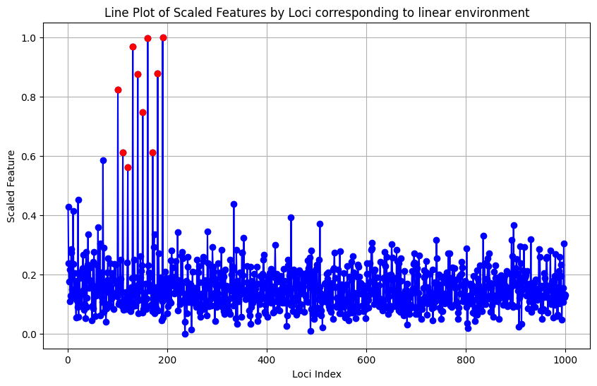

```python
plot_feature_importance(GenFeat_df=DeepFeatImp_df.copy(),actual_pos = actual_pos)
```

### 2) DeepExplainer method

**Feature Importance based on five iterations of model training (iteration =5)**

```python
DeepExplainer_df = feature_importance(input_data=X_data, output_data=y_data, feature_set=X_data.columns.to_list(), iteration=5,
                                      feature_method="DeepExplainer",model_file = "Bayesian_NN_architecture_HP.keras")
```

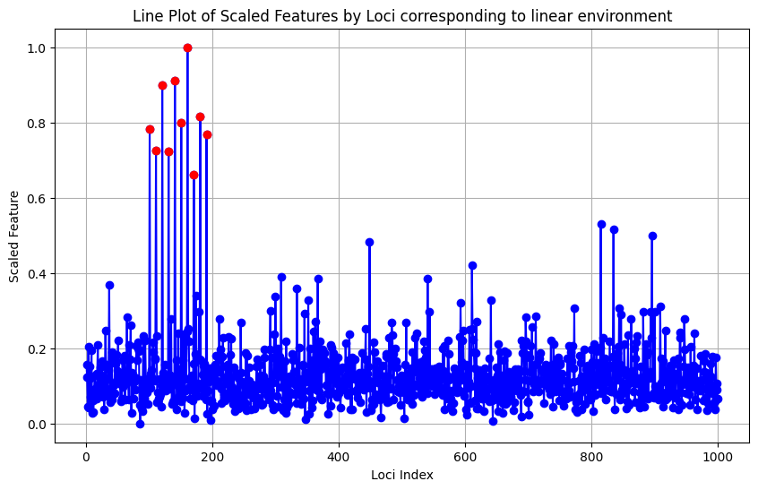

```python
plot_feature_importance(GenFeat_df=DeepExplainer_df.copy(),actual_pos = actual_pos)
```

### 3) KernelExplainer method

```python
KernelExplainer_df = feature_importance(input_data=X_data, output_data=y_data, feature_set=X_data.columns.to_list(), iteration=1,
                                        feature_method="KernelExplainer",nsamples=10,model_file = "Bayesian_NN_architecture_HP.keras")
```

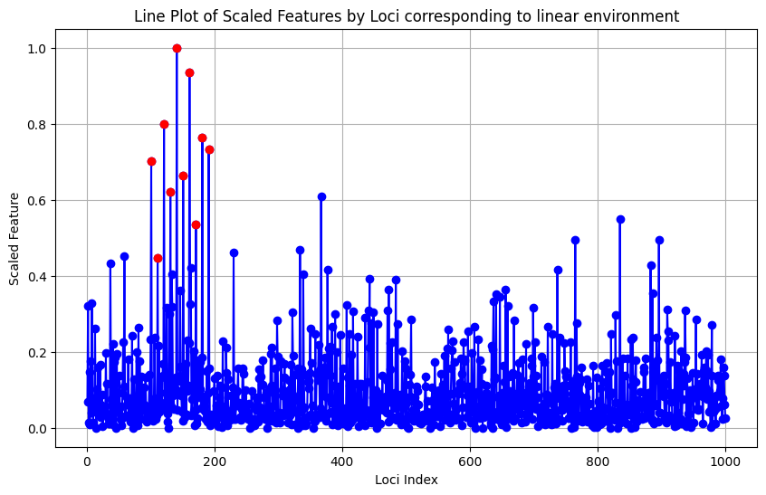

```python
plot_feature_importance(GenFeat_df=KernelExplainer_df.copy(),actual_pos = actual_pos)
```

## Binary classification example with Bayesian optimization method and DeepFeatImp

We will use breast cancer dataset from scikit-learn for the binary classification demonstration

https://scikit-learn.org/stable/modules/generated/sklearn.datasets.load_breast_cancer.html

```python
from sklearn.datasets import load_breast_cancer

X_data, y_data = load_breast_cancer(return_X_y=True, as_frame=True)
y_data = pd.DataFrame(y_data)
```

```python
Bayesian_tune_model_binary = hp_optimization(input_data=X_data, output_data=y_data, objective_fun="val_loss", output_class="binary",
                                      algorithm = "Bayesian",model_file = "Bayesian_binary_NN_architecture_HP.keras", max_trials=20)
```

```python
print(Bayesian_tune_model_binary.summary())
```

```python
DeepFeatImp_df_binary = feature_importance(input_data=X_data, output_data=y_data, feature_set=X_data.columns.to_list(),iteration=10,
                                    output_class = "binary",feature_method="DeepFeatImp",
                                    model_file = "Bayesian_binary_NN_architecture_HP.keras")
```

```python
DeepFeatImp_df_binary["scaled_feat"] = minmaxscale(vec = DeepFeatImp_df_binary["target"])
DeepFeatImp_df_binary = DeepFeatImp_df_binary.sort_values(by='target', ascending=False)
```

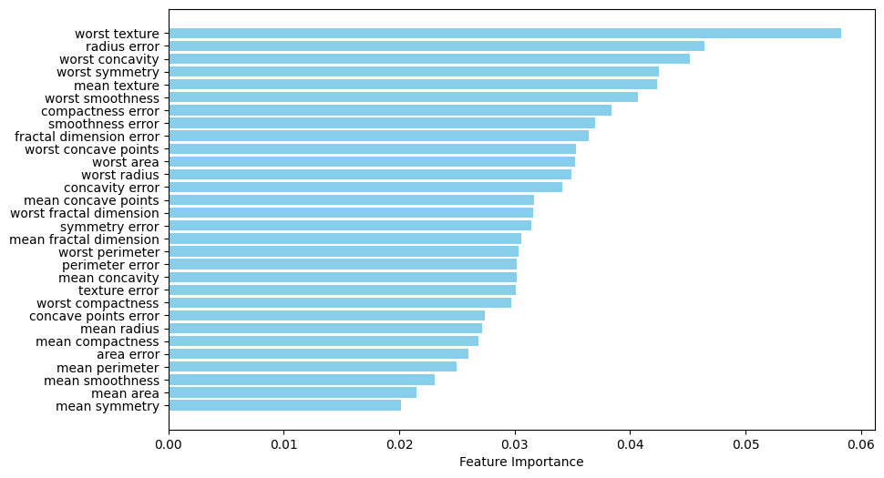

```python
plt.figure(figsize=(10, 6))
plt.barh(DeepFeatImp_df_binary['features'], DeepFeatImp_df_binary['target'], color='skyblue')
plt.xlabel('Feature Importance')
plt.gca().invert_yaxis()  # Invert y-axis to have the highest importance at the top
plt.show()
```